# HW 5

Heath Blackmon

2/14/2018

### Chapter 7 number 24

Each member of a large genetics class grows 12 pea plans from an independent pea family. Each family is expect to have 3/4 plants with smooth peas and 1/4 plants with wrinkled peas.

#### A

On average, how many wrinkled pea plants will a student see in her 12 plants?

```r
ybar <- 12 * 1/4
```

*On average as student should see 3 wrinkled pea plants.*

#### B

What is the standard deviation of the proportion of wrinkled pea plants per a student?

```r
# formula from page 189
p <- .25
n <- 12
sd <- sqrt(p*(1-p)/n)
```

*The standard deviation of the proportion of wrinkled pea plants per a student is 0.125.*

#### C

What is the variance in the proportion of wrinkled pea plants per a student?

```r
p <- .25
n <- 12
sd <- sqrt(p*(1-p)/12)
calc.var <- sd^2
```

*The variance in the proportion of wrinkled pea plants per a student is 0.015625.*

#### D

Predict the proportion of students that saw exactly two wrinkled pea plants in their sample.

```r
p_2 <- round(dbinom(x=2, size = 12, prob=.25), digits = 3)
```

*The proportion of students that should find exactly two wrinkled pea plants is 0.232.*

### Chapter 8 number 14

Testing the effect of window angle on bird impact deaths. Treatments were vertical, 20, or 40 degrees off vertical. During the experiment 30, 15, and 8 birds were killed by each type of window respectively

#### A

Clearly state a null and alternative hypothesis *null: Window has no impact on the likelihood of a bird impacting a window*

*alternative: The closer to vertical the greater the likelihood of a bird impact.*

#### B

What proportion of deaths were in vertical windows

```r
deaths <- c(30, 15, 8)
p_v <- deaths[1]/sum(deaths)
```

*The proportion of death from vertical windows is 0.5660377.*

#### C

What statistical test could you use to test the null?

*I could use the chi square test to evaluate the null.*

#### D

Is there evidence that window angle affects the mortality rate of birds?

```r
result <- chisq.test(deaths)
```

Our experiment indicates that the mortality rate of birds does differ among window angles ($\chi^2$=14.302 p-value=0.001)

### Chapter 9 number 24

32 of 50 French Drosophila are sterile at high temperature. 20 of 50 Indian Drosophila are sterile at high temperature.

#### A

Is this observational or experimental? *observational*

#### B

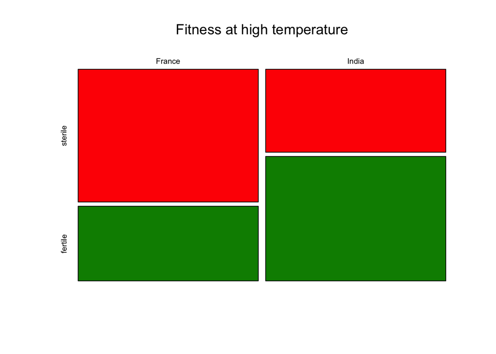

```r
flies <- matrix(c(32,20,18,30),2,2)
colnames(flies) <- c("sterile", "fertile")
row.names(flies) <- c("France", "India")
mosaicplot(flies, col = c("red","green4"),main="Fitness at high temperature")
```

This suggests that perhaps flies from India are able to deal with high temperature better than flies from France.

#### C

Is there evidence that the flies from these two locations differ?

```r
result <- chisq.test(flies)
```

The experiment indicates that the sterility rate of flies does differ among the two populations ($\chi^2$=4.848 p-value=0.028)

#### D

Calculate the relative risk of sterility in drosophila from India to France. Include the 95% confidence interval. Formula is on 256.

```r
a <- 20
b <- 32
c <- 30
d <- 18
p1 <- a / (a + c)
p2 <- b / (b + d)
RR <- p1/p2
SE <- sqrt(1/a + 1/b - 1/(a+c) - 1/(b+d))
low <- exp(log(RR) - 1.96*SE)
high <- exp(log(RR) + 1.96*SE)
```

The relative risk of sterility in the Indian population is 0.625 with a 95% confidence interval from 0.4197561 to 0.9306.

### Chapter 9 number 27

Is the pattern of health deterioration different in the two groups?

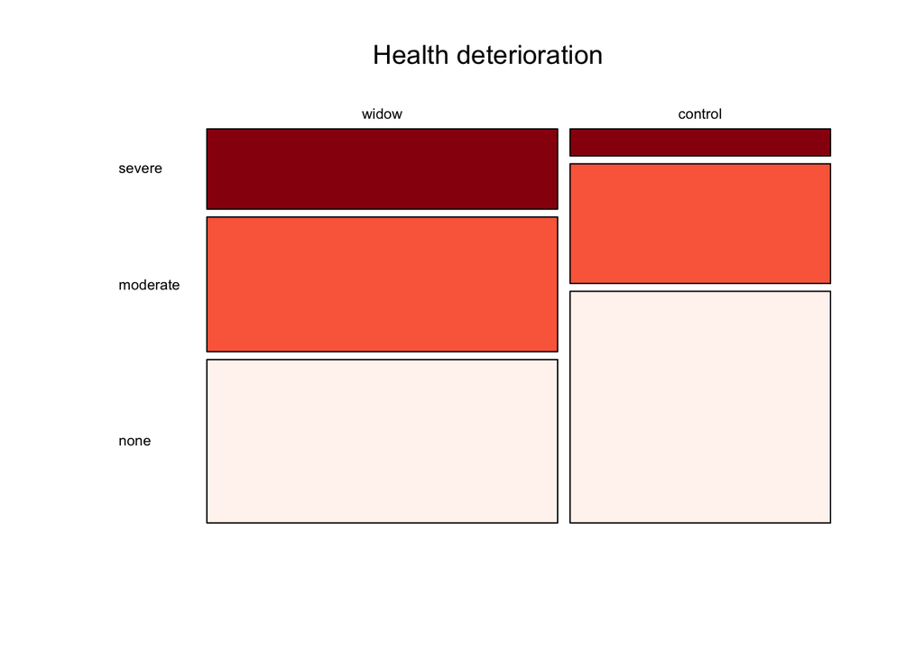

```r
health <- matrix(c(28,47,57,7,31,60),3,2)
colnames(health) <- c("widow", "control")
row.names(health) <- c("severe", "moderate", "none")
mosaicplot(t(health), main="Health deterioration", col=c("#99000d","#fb6a4a","#fff5f0"), las=1)
```

We can use a simple chi square test to evaluate.

```r
result <- chisq.test(health)
```

The experiment indicates that the health decline of widows does differ from the control group ($\chi^2$=11.177 p-value=0.004)